# Proyecto Inferencia Estadística - Parte 1 (Punto A)

Pablo Gonzalez B.

26/1/2022

## Punto A

Para este punto consideramos una muestra aleatoria $X_1, ..., X_n$ de una distribución $U[0, \theta = 3]$, sabiendo que $\hat{\theta}_{MLE} = X^{(n)}$.

Antes de empezar, importamos las librerías necesarias para la correcta ejecución del código.

```r
library(ggplot2)
library(Brobdingnag)
require(latex2exp)
```

#### Literal a)

A continuación definimos una función que nos permite generar $m$ simulaciones de una muestra aleatoria de tamaño $n$ de la distribución $U[0, \theta = 3]$. En esta función, para cada simulación almacenamos la estimación maximo-verosimil en la variable `MLE` tomando el valor máximo de la muestra de tamaño $n$ y posteriormente generamos un histograma de todas las estimaciones MLE sobrelapando la función de densidad teórica de $X^{(n)}$ que la calculamos como:
$$f_{X^{(n)}}(x) =nf_X(x)\cdot [F_X(x)]^{n-1} = \frac{n}{3}\cdot\Big(\frac{x}{3}\Big)^{n-1} = \frac{nx^{n-1}}{3^n}$$
y la función de densidad teórica de $X^{(n)}$ viene definida como:

```r
densidad_teorica_Xn <- function(x, nParam, kappa = 3) {
  (nParam/kappa) * (x/kappa)^(nParam-1)
}
```

Entonces la función que nos permite generar $m$ simulaciones queda definida de la siguiente manera:

```r
generarSimulacion <- function(kappa = 3, m = 1000, n) {
  estimaciones = list()

  # Calcular y almacenar la estimación MLE de cada muestra.
  for (i in 1:m) {
    muestra = runif(n, min = 0, max = kappa)
    MLE = max(unlist(muestra))
    estimaciones[i] = MLE
  }

  # Generar histograma con función de densidad teórica de X^(n)
  estimacionesMLE = unlist(estimaciones, use.names = FALSE)

  xfit = seq(0, 3, 1/(n+1))

  hist(estimacionesMLE,
       breaks = 20,
       prob = TRUE,
       col = "lightgray",
       xlab="",
       ylab="Histograma",
       main=paste0("Histograma con realizaciones MLE \n Muestra de tamaño n = ", n))

  lines(xfit, densidad_teorica_Xn(xfit, nParam = n, kappa = kappa), from = 0, to = 3, ylab="", xlab="", col = "blue", type = "b", pch = 18, lty = 2)

  legend("topleft", legend="Función de densidad teorica de X^n",
       col="blue", lty=2, cex=0.8, pch=18)
}
```

Ejecutando la función con los parámetros $m = 1000, \ n = 10$ obtenemos la siguiente gráfica:

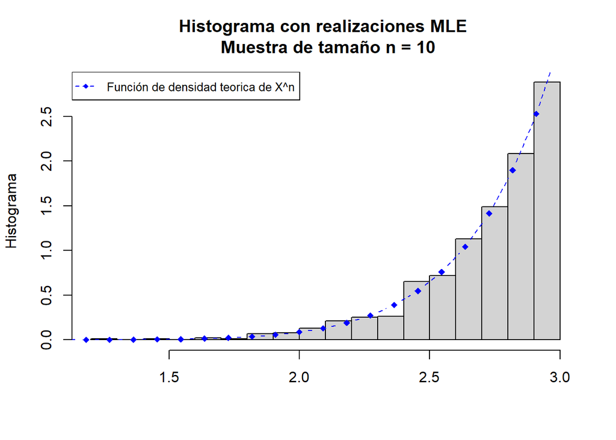

#### Literal b)

Ahora en este caso repetiremos la simulación para $n = 50, 100, 200, 500, 1000$:

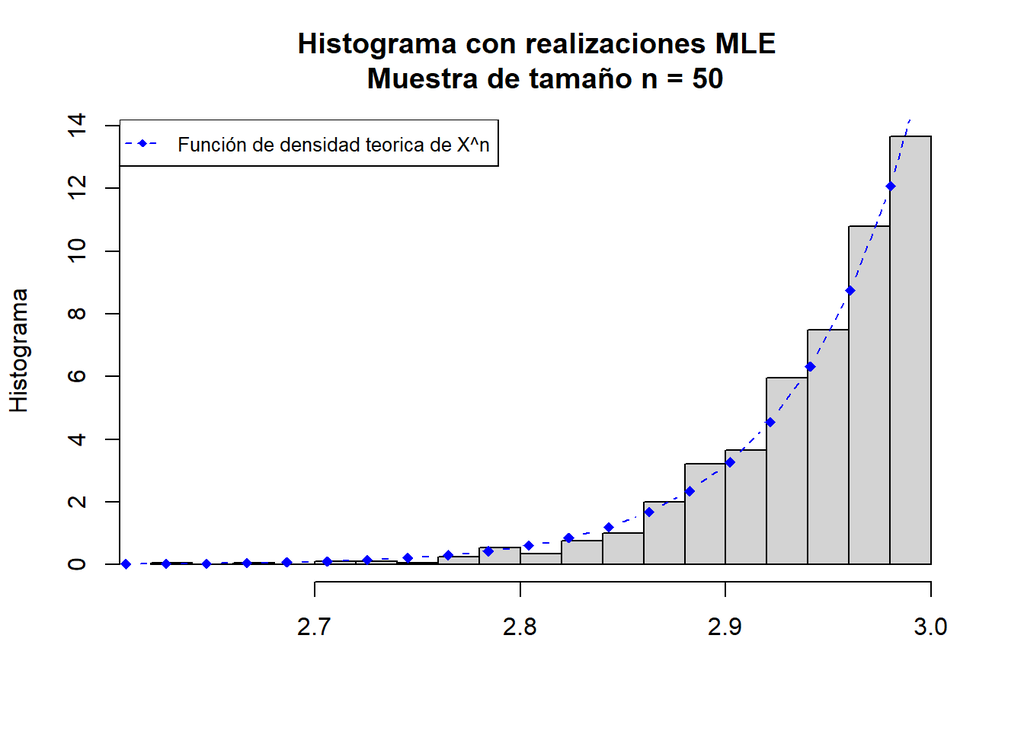

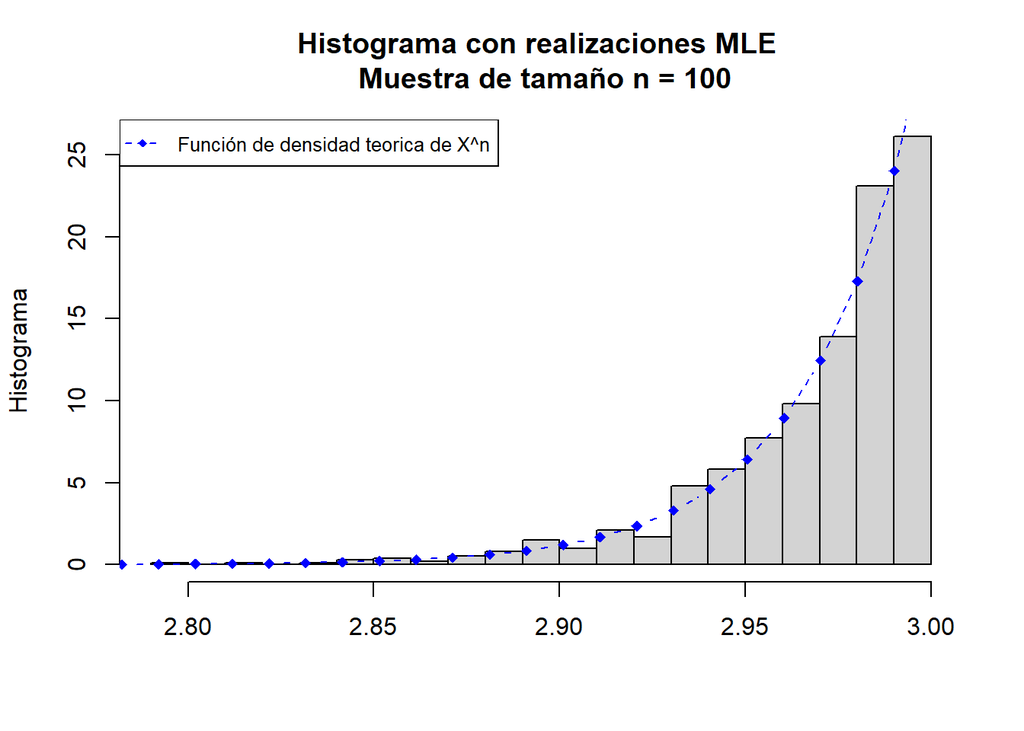

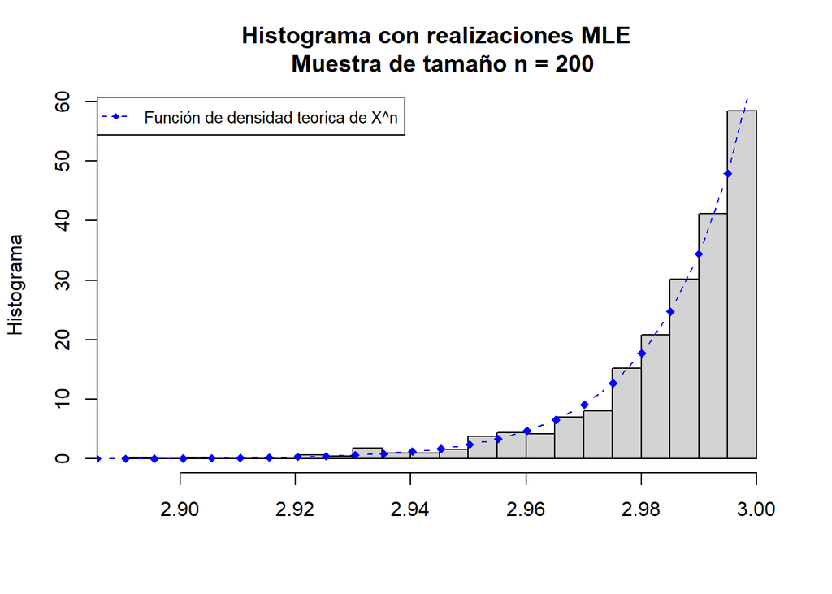

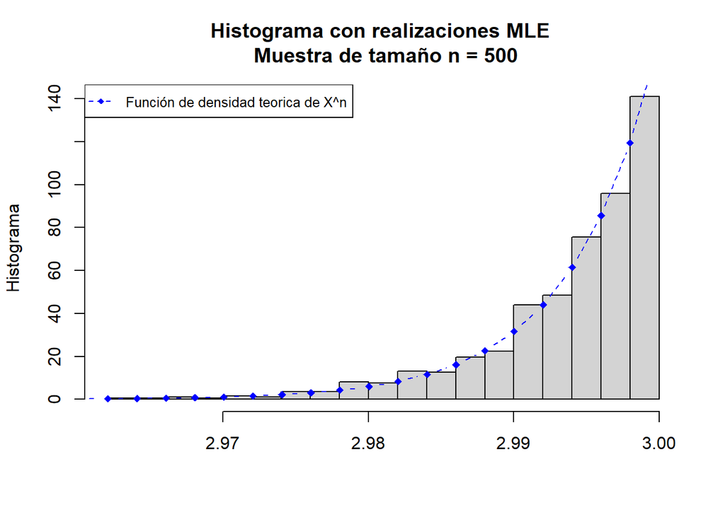

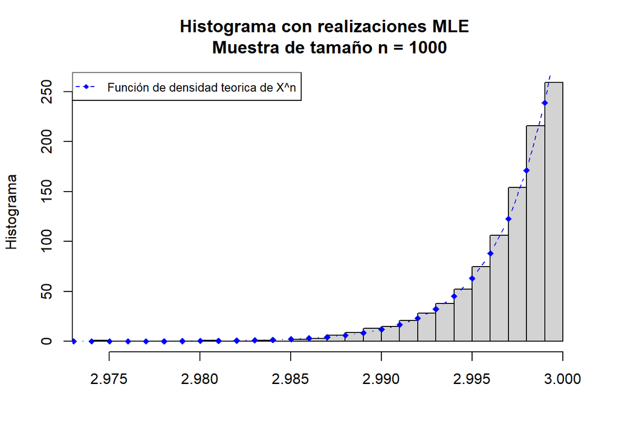

#### Literal c)

A medida que el tamaño de la muestra aumenta, vemos que el valor de la realización del estimador máximo-verosímil se concentra en el valor $3.0$. Además la pendiente de la función de densidad teorica se vuelve mas inclinada de manera positiva.

#### Literal d)

Ahora, para este literal queremos generar $m$ muestras de tamaños $n = 10, 50, 100, 200, 500, 1000$, y para cada una de estas muestras queremos almacenar las $m$ realizaciones de $R_n$ que viene definida como sigue:
$$R_n = n(\theta - X^{(n)})$$

Por lo tanto para realizar esto definimos la siguiente función:

```r
generarSimulacionRn <- function(kappa = 3, m = 1000, n) {
  realizaciones_Rn = list()

  # Calcular y almacenar la realizacion R_n de cada muestra.
  for (i in 1:m) {
    muestra = runif(n, min = 0, max = kappa)
    MLE = max(unlist(muestra))
    realizaciones_Rn[i] = n*(kappa - MLE)
  }

  # Generar histograma con función de densidad teórica de X^(n)
  realizaciones_Rn = unlist(realizaciones_Rn, use.names = FALSE)

  hist(realizaciones_Rn,
       breaks = 30,
       prob = TRUE,
       col = "lightgray",
       xlab="",
       ylab="Histograma",
       main=paste0("Histograma con realizaciones de R_n \n Muestra de tamaño n = ", n))
}
```

Ya definida la función la ejecutamos para los valores $n = 10, 50, 100, 200, 500, 1000$:

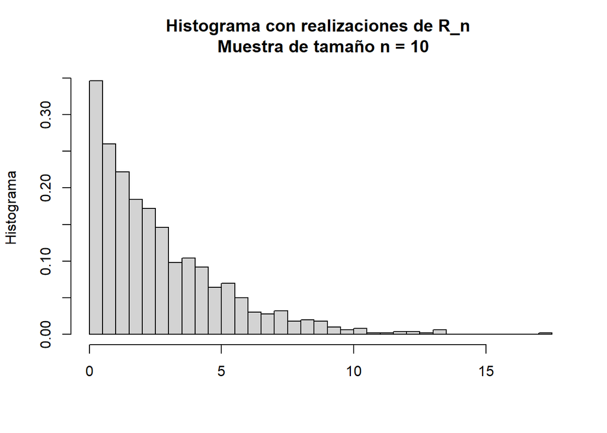

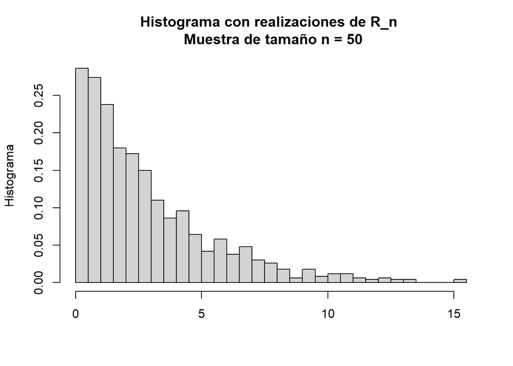

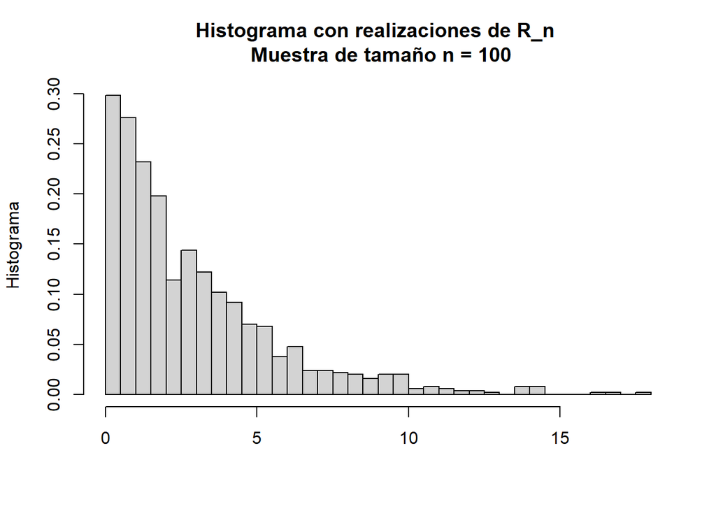

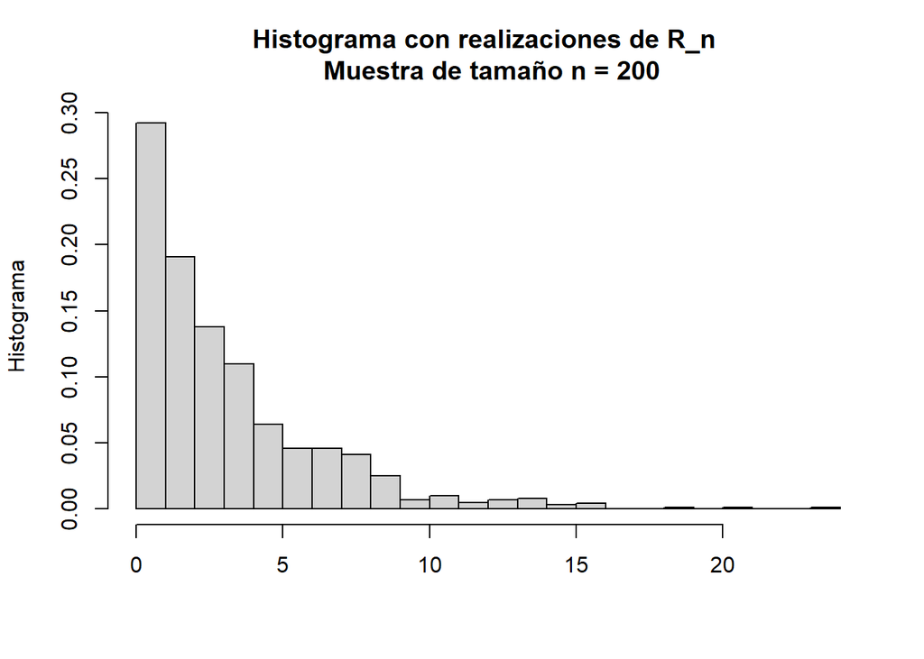

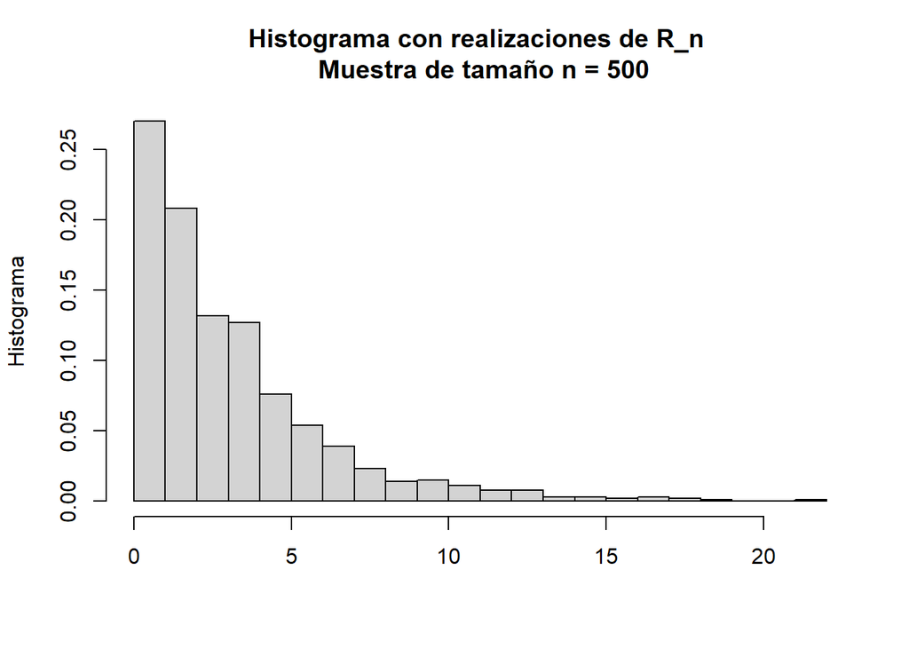

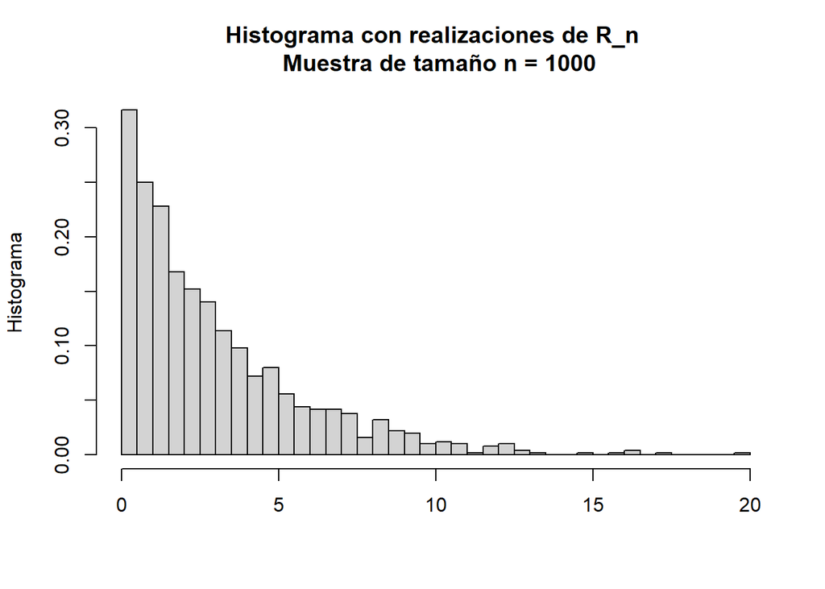